# lab6_Kondratiuk

**Мета:** *навчитися писати функції та користуватися ними*

::: callout-note

## Примітка

Попередньо потрібно опрацювати лекцію 6. :::

::: callout-note

## Примітка

У лабораторній роботі використано матеріали [python institute.](https://pythoninstitute.org/pcep) :::

## Що ви будете вміти?

- створювати користувацькі функції.
- викликати користувацькі функції з параметрами та без.
- освоїте обробку списків за допомогою функцій.

## Створення функції

Приклад функції з одним параметром і без ключового слова `return`:

```python
def hi(name):
    print("Hi,", name)

hi("Greg")
```

```
Hi, Greg
```

Приклад функції з ключовим словом `return`:

```python
def strange_function(n):
    if(n % 2 == 0):
        return True

print(strange_function(2))
print(strange_function(1))
```

```
True
None
```

### Завдання 1

Написати і протестувати функцію, яка приймає один аргумент (рік) і повертає `True`, якщо рік є високосним, або `False` інакше.

Основу функції вже закладено у коді в редакторі.

::: callout-note

## Примітка

Для вас підготовлено короткий тестуючий код, який можна використовувати для перевірки своєї функції. :::

У коді використовуються два списки - один із тестовими даними, інший - з очікуваними результатами. Код повідомить Вам, якщо якісь із Ваших результатів неправильні.

```python
def is_year_leap(year):
    if ((year % 4 == 0 and year % 100 != 0) or year % 400 == 0):
        return True
    else: return False

test_data = [1900, 2000, 2016, 1987]
test_results = [False, True, True, False]
for i in range(len(test_data)):
    yr = test_data[i]
    print(yr,"->",end="")
    result = is_year_leap(yr)
    if result != test_results[i]: print("Failed")
    else: print("OK")
```

```
1900 ->OK
2000 ->OK
2016 ->OK
1987 ->OK
```

### Завдання 2

Написати та протестувати функцію, яка приймає два аргументи (рік і місяць) і повертає кількість днів для даної пари рік-місяць (у той час, як тільки лютий чутливий до значення `year`, Ваша функція має бути універсальною).

Початок функції готовий. Тепер переконайте функцію повернути `None`, якщо її аргументи не мають сенсу.

Звичайно, Ви можете (і повинні) використовувати раніше написану та протестовану функцію (див. попередні лаб. роб.). Це може бути дуже корисним. Ми рекомендуємо використовувати список із зазначенням довжини місяців. Ви можете створити його всередині функції – цей трюк значно скоротить код.

Ми підготували тестуючий код. Розвійте його, щоб увімкнути більше тестових випадків.

```python
def is_year_leap(year):
    if (year % 4 == 0 and year % 100 != 0) or year % 400 == 0:
        return True

def days_in_month(year, month):
    x = [4, 6, 9, 11]
    if month != 2:
        if month in x: days = 30
        else: days = 31
    else:
        if is_year_leap(year): days = 29
        else: days = 28
    return days

test_years = [1900, 2000, 2016, 1987]
test_months = [2, 2, 1, 11]
test_results = [28, 29, 31, 30]
for i in range(len(test_years)):
    yr = test_years[i]
    mo = test_months[i]
    print(yr, mo, "->", end="")
    result = days_in_month(yr, mo)
    if result == test_results[i]:
        print("OK")
    else:
        print("Failed")
```

[output not shown]

### Завдання 3

Написати та протестувати функцію, яка приймає три аргументи (рік, місяць та день місяця) та повертає відповідний день року або None, якщо якийсь із аргументів невірний.

Використовуйте раніше написані та протестовані функції. Додайте до коду свої власні тестові випадки.

```python
def is_year_leap(year):
    if (year % 4 == 0 and year % 100 != 0) or year % 400 == 0:
        return True

def days_in_month(year, month):
    x = [4, 6, 9, 11]
    if month != 2:
        if month in x: days = 30
        else: days = 31
    else:
        if is_year_leap(year): days = 29
        else: days = 28
    return days
def day_of_year(year, month, day):
    sum=day
    for i in range(1,month):
        sum+=days_in_month(year, i)
    return sum

print(day_of_year(400, 12, 31))
```

[output not shown]

### Завдання 4

Натуральне число є простим, якщо воно більше 1 і не має дільників, крім 1 і самого себе.

Важко? Зовсім ні. Наприклад, 8 не є простим числом, оскільки Ви можете розділити його на 2 та 4 (ми не можемо використовувати дільники, рівні 1 та 8, оскільки визначення забороняє це).

Ваше завдання - написати функцію, що перевіряє, чи є число простим чи ні.

Функція:

- називається `is_prime`;
- приймає один аргумент (значення для перевірки)
- повертає `True`, якщо аргумент є простим числом, і `False` інакше.

::: callout-note

## Підказка

Спробуйте розділити аргумент на всі наступні значення (починаючи з 2) і перевірте залишок - якщо він дорівнює нулю, Ваше число не може бути простим; добре подумайте, коли вам слід зупинити процес. :::

Якщо вам потрібно знайти квадратний корінь із будь-якого значення, Ви можете використовувати оператор `**`. Пам'ятайте: квадратний корінь `x` дорівнює $x^{0,5}$.

Доповніть код у редакторі.

```python
def is_prime(num):
    if num != 0 and num != 1 and num != 2 and num != 3 and num != 5:
        if num % 2 == 0 or num % 3 == 0 or num % 5 == 0:
            return False
        else:
            return True
    else:
        return True

for i in range(1, 20):
    if is_prime(i + 1):
        print(i + 1, end=" ")
```

[output not shown]

### Очікуваний вивод

`2 3 5 7 11 13 17 19`

### Завдання 5

Витрата палива автомобіля можна висловити по-різному. Наприклад, у Європі він відображається як кількість витраченого палива на 100 кілометрів шляху.

У США він відображається як кількість миль, пройдених автомобілем під час витрачання одного галону палива.

Ваше завдання - написати дві функції, що конвертують л/100км в миль на галон, і навпаки.

Функції:

- названі `liters_100km_to_miles_gallon` та `miles_gallon_to_liters_100km` відповідно;
- приймають один аргумент (значення, що відповідає їхнім іменам)

Доповніть код у редакторі.

Запустіть свій код і перевірте, чи Ваш результат збігається з нашим.

Ось деяка інформація, яка може допомогти Вам:

- 1 американська мідя = 1609.344 метрів;
- 1 американський галон = 3.785411784 літрів.

```python
def liters_100km_to_miles_gallon(liters):
    gallon=liters/3.785411784
    miles=0.62137*100
    return miles/gallon

def miles_gallon_to_liters_100km(gallon):
    liters = 3.785411784/gallon
    km = 0.62137*100
    return liters*km

print(liters_100km_to_miles_gallon(3.9))
print(liters_100km_to_miles_gallon(7.5))
print(liters_100km_to_miles_gallon(10.))
print(miles_gallon_to_liters_100km(60.3))
print(miles_gallon_to_liters_100km(31.4))
print(miles_gallon_to_liters_100km(23.5))
```

[output not shown]

### Очікуваний вивод

`60.31143162393162`  
`31.36194444444444`  
`23.52145833333333`  
`3.9007393587617467`  
`7.490910297239916`  
`10.009131205673757`

### Приклад 1

Давайте напишемо функцію оцінки індексу маси тіла (ІМТ, BMI). $$BMI = \frac{m}{h^2}$$ тут $m$ -- маса у *кг*, $h$ -- зріст у *м*.

```python
def bmi(weight, height):
    return weight / height ** 2


print(bmi(52.5, 1.65))
```

```
19.283746556473833
```

### Ключове слово `None`

Функція у попередньому прикладі виправдовує наші очікування, але вона дещо проста – вона припускає, що значення обох параметрів завжди мають сенс. Варто перевірити, чи заслуговують вони на довіру.

Давайте перевіримо їх обидва і повернемо `None`, якщо якесь з них виглядає підозріло.

```python
def bmi(weight, height):
    if height < 1.0 or height > 2.5 or \
    weight < 20 or weight > 200:
        return None

    return weight / height ** 2


print(bmi(352.5, 1.65))
```

```
None
```

### Завдання 6

Написати функцію, яка перевіряє, чи три сторони заданої довжини побудувати трикутник. Вона має повернути `True`, якщо сторони можуть утворити трикутник, і `False` в іншому випадку. У цьому випадку `is_a_triangle(a, b, c)` – гарна назва для такої функції.

```python
def is_a_triangle(a, b, c):
    #Сума будь-яких двох сторін має бути більшою за третю
    if (a + b > c) and (b + c > a) and (a + c > b): return True
    else: return False
```

### Завдання 7

Написати функцію `is_a_right_triangle(a, b, c)`, яка перевіряє, чи є трикутник зі сторонами `a`, `b`, `c` прямокутним. При цьому потрібно використати функцію `is_a_triangle(a, b, c)` з завдання 6.

```python
def is_a_right_triangle(a, b, c):
    if is_a_triangle(a, b, c):
        #Визначення гіпотенузи (найбільше число)
        sides = [a, b, c]
        sides.sort()
        a, b, c = sides

        #Теорема Піфагора
        if a**2 + b**2 == c**2:
            return True
        else:
            return False
    else:
        return False
```

## Завдання для самостіної роботи

1. Виконати завдання 1-7 наведені вище у цьому зошиті.
2. Створити файл **lab_6_StudentLastName.py** з написаним кодом.
3. Закомітити файл у локальний репозиторій.
4. Відправити ("запушити") поточну версію Git-проєкта у віддалений репозиторій на GitHub.
5. Звіт має складатися з файлу (за основу взяти **цей Python-зошит**) `lab_6_StudentLastName.ipynb`. (Можливі якісь додакові файли)

## Контрольні запитання

1. Який вивод наступного фрагмента?

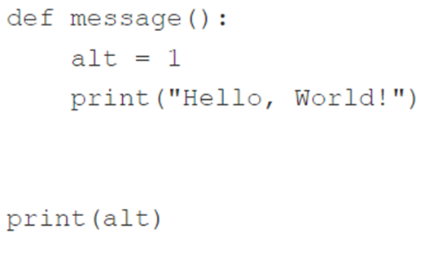

   Помилка
2. Який вивод наступного фрагмента?

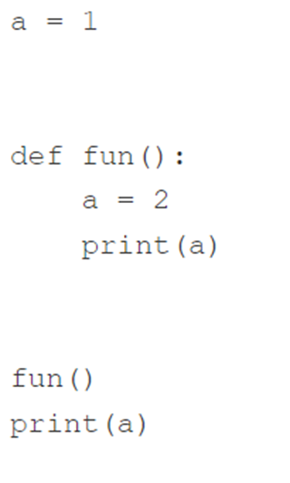

   2 1
3. Який вивод наступного фрагмента?

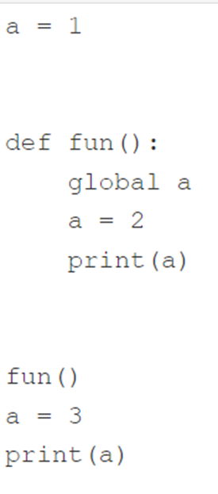

   2 3
4. Який вивод наступного фрагмента?

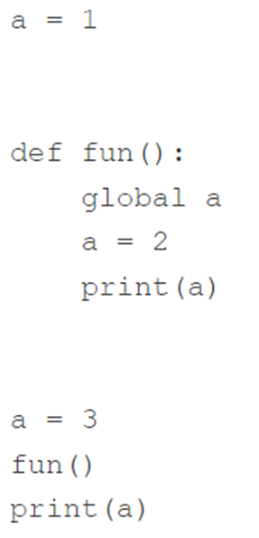

   2 2

## References

1. Anaconda (Python distribution))
2. [Conda](https://conda.io/en/latest/)
3. [Pro Git Book](https://git-scm.com/book/en/v2)
4. [OpenEDG Python Institute](https://pythoninstitute.org/)
5. [Cisco. Networking Academy](https://www.netacad.com/)
6. [Научно-издательская система Quarto](https://data-visualization-blog.netlify.app/posts/quarto/)